# 02_SpilloverCompensation_cells_Compressed

## Pixel binning

Consecutive pixels are summed to increase the robustness of the spillover estimation. No signal should be observed off the diagonal on the thresholded heatmap. If that is the case, reduce the bin size.

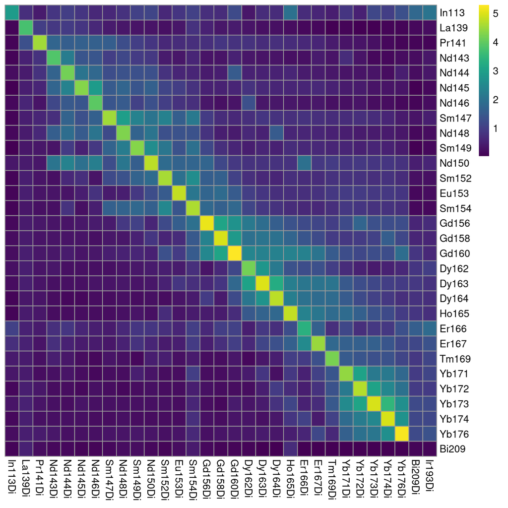

```r
# Pixel binning
bin_size <- 20

sce <- binAcrossPixels(sce, spot_id = "metal", bin_size = bin_size)
assay(sce, "exprs") <- asinh(counts(sce)/5)

## Plot binned heatmaps.
plotSpotHeatmap(sce, spot_id = "metal", statistic = "mean", cluster_rows = FALSE, cluster_cols= FALSE,
  order_metals = TRUE, assay_type = "counts")
```

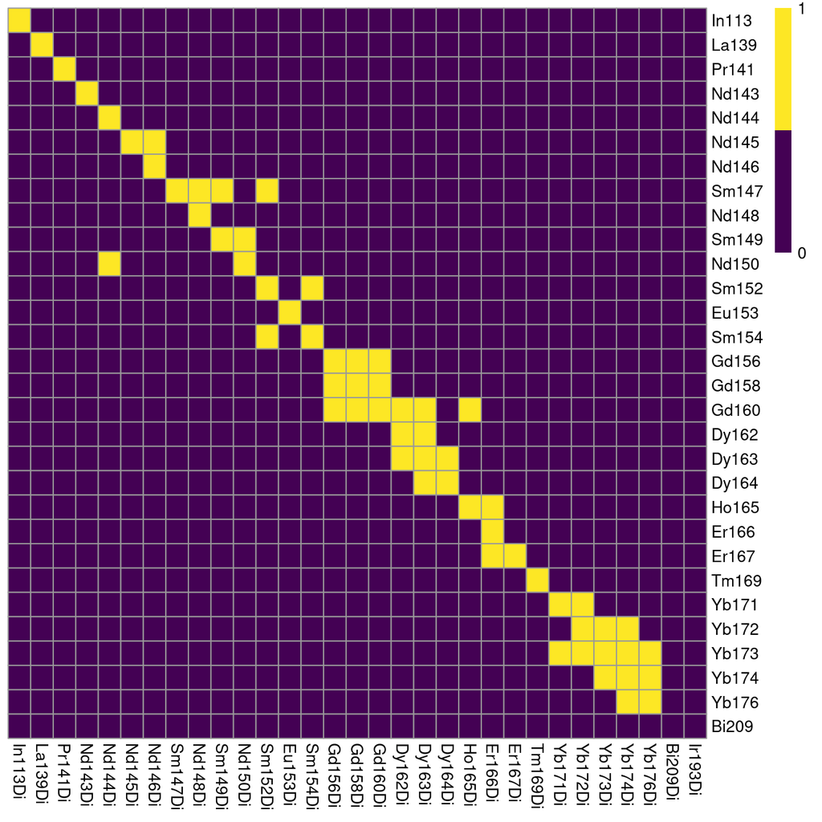

```r
## Binned + Thresholded heatmaps:
plotSpotHeatmap(sce, spot_id = "metal", log = FALSE, threshold = 200,
  cluster_rows = FALSE, cluster_cols= FALSE, order_metals = TRUE, assay_type = "counts")
```

## Filter pixels

### Debarcoding and pixel assignment

```r
# Get correct key.
bc_key <- as.numeric(unique(sce$sample_mass))
bc_key <- bc_key[order(bc_key)]

sce <- assignPrelim(sce, bc_key = bc_key)
```

```
Debarcoding data...
```

```
 o ordering
```

```
 o classifying events
```

```
Normalizing...
```

```
Computing deltas...
```

```r
sce <- estCutoffs(sce)
sce <- applyCutoffs(sce)

cur_table <- table(sce$bc_id, sce$sample_mass)
cur_table
```

```
      113 139 141 143 144 145 146 147 148 149 150 152 153 154 156 158 160 162
  0    50  41  40  27  33  43  38  47  35  45  42  42  42  43  41  41  42  34
  113  50   0   0   0   0   0   0   0   0   0   0   0   0   0   0   0   0   0
  139   0  59   0   0   0   0   0   0   0   0   0   0   0   0   0   0   0   0
  141   0   0  60   0   0   0   0   0   0   0   0   0   0   0   0   0   0   0
  143   0   0   0  73   0   0   0   0   0   0   0   0   0   0   0   0   0   0
  144   0   0   0   0  67   0   0   0   0   0   0   0   0   0   0   0   0   0
  145   0   0   0   0   0  57   0   0   0   0   0   0   0   0   0   0   0   0
  146   0   0   0   0   0   0  62   0   0   0   0   0   0   0   0   0   0   0
  147   0   0   0   0   0   0   0  53   0   0   0   0   0   0   0   0   0   0
  148   0   0   0   0   0   0   0   0  65   0   0   0   0   0   0   0   0   0
  149   0   0   0   0   0   0   0   0   0  55   0   0   0   0   0   0   0   0
  150   0   0   0   0   0   0   0   0   0   0  58   0   0   0   0   0   0   0
  152   0   0   0   0   0   0   0   0   0   0   0  58   0   0   0   0   0   0
  153   0   0   0   0   0   0   0   0   0   0   0   0  58   0   0   0   0   0
```

[output cut: 48 more lines]

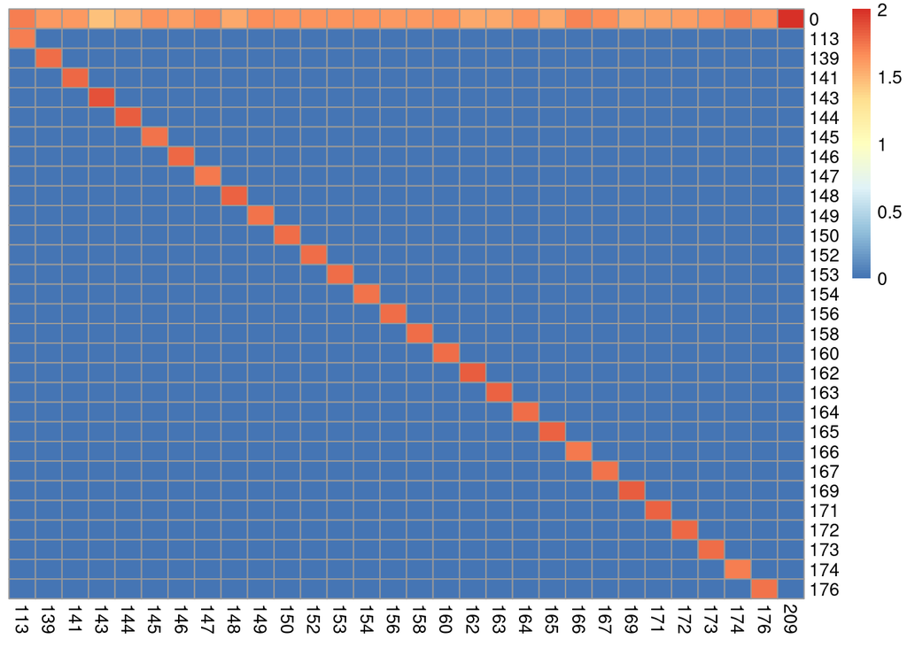

```r
library(pheatmap)
cur_table <- table(sce$bc_id, sce$sample_mass)

# Visualize the correctly and incorrectly assigned pixels
pheatmap(log10(cur_table + 1),
         cluster_rows = FALSE,
         cluster_cols = FALSE)
```

```r
# Compute the fraction of unassigned pixels per spot
cur_table["0",] / colSums(cur_table)
```

```
 113  139  141  143  144  145  146  147  148  149  150  152  153  154  156  158
0.50 0.41 0.40 0.27 0.33 0.43 0.38 0.47 0.35 0.45 0.42 0.42 0.42 0.43 0.41 0.41
 160  162  163  164  165  166  167  169  171  172  173  174  176  209
0.42 0.34 0.35 0.42 0.35 0.48 0.45 0.34 0.36 0.38 0.42 0.49 0.43 1.00
```

# **Compute spillover matrix**

## Compute and plot spillover matrix

Functions from the [CATALYST package](https://bioconductor.org/packages/release/bioc/html/CATALYST.html) are used to compute the spillover matrix and visualize it.

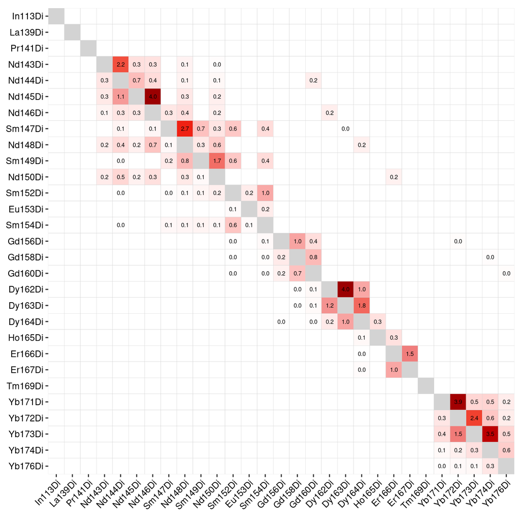

```r
sce <- computeSpillmat(sce)

isotope_list <- CATALYST::isotope_list
isotope_list$Ar <- 80

plotSpillmat(sce, isotope_list = isotope_list)
```

Save Spillover matrix in the metadata of the SCE object + as external csv.

```r
# Save spillover matrix in variable
sm <- metadata(sce)$spillover_matrix

write.csv(sm, "sm.csv")
```